# Part I - (FordGoBike System Data)

## Introduction

> This data set includes information about individual rides made in a bike-sharing system covering the greater San Francisco Bay area.

## Preliminary Wrangling

```python
# import all packages and set plots to be embedded inline
import numpy as np
import pandas as pd
import matplotlib.pyplot as plt
import seaborn as sns
import requests
import os
import glob

%matplotlib inline
```

*Load in the dataset into a pandas dataframe, print statistics*

```python
df = pd.read_csv('201902-fordgobike-tripdata.csv')
df.head()
```

|  | duration_sec | start_time | end_time | start_station_id | start_station_name | start_station_latitude | start_station_longitude | end_station_id | end_station_name | end_station_latitude | end_station_longitude | bike_id | user_type | member_birth_year | member_gender | bike_share_for_all_trip |
| --- | --- | --- | --- | --- | --- | --- | --- | --- | --- | --- | --- | --- | --- | --- | --- | --- |
| 0 | 52185 | 2019-02-28 17:32:10.1450 | 2019-03-01 08:01:55.9750 | 21.0 | Montgomery St BART Station (Market St at 2nd St) | 37.789625 | -122.400811 | 13.0 | Commercial St at Montgomery St | 37.794231 | -122.402923 | 4902 | Customer | 1984.0 | Male | No |
| 1 | 42521 | 2019-02-28 18:53:21.7890 | 2019-03-01 06:42:03.0560 | 23.0 | The Embarcadero at Steuart St | 37.791464 | -122.391034 | 81.0 | Berry St at 4th St | 37.775880 | -122.393170 | 2535 | Customer | NaN | NaN | No |
| 2 | 61854 | 2019-02-28 12:13:13.2180 | 2019-03-01 05:24:08.1460 | 86.0 | Market St at Dolores St | 37.769305 | -122.426826 | 3.0 | Powell St BART Station (Market St at 4th St) | 37.786375 | -122.404904 | 5905 | Customer | 1972.0 | Male | No |
| 3 | 36490 | 2019-02-28 17:54:26.0100 | 2019-03-01 04:02:36.8420 | 375.0 | Grove St at Masonic Ave | 37.774836 | -122.446546 | 70.0 | Central Ave at Fell St | 37.773311 | -122.444293 | 6638 | Subscriber | 1989.0 | Other | No |
| 4 | 1585 | 2019-02-28 23:54:18.5490 | 2019-03-01 00:20:44.0740 | 7.0 | Frank H Ogawa Plaza | 37.804562 | -122.271738 | 222.0 | 10th Ave at E 15th St | 37.792714 | -122.248780 | 4898 | Subscriber | 1974.0 | Male | Yes |

```python
# high-level overview of data shape and composition
print(df.shape)
print(df.dtypes)
```

```
(183412, 16)
duration_sec                 int64
start_time                  object
end_time                    object
start_station_id           float64
start_station_name          object
start_station_latitude     float64
start_station_longitude    float64
end_station_id             float64
end_station_name            object
end_station_latitude       float64
end_station_longitude      float64
bike_id                      int64
user_type                   object
member_birth_year          float64
member_gender               object
bike_share_for_all_trip     object
dtype: object
```

```python
df.head(10)
```

|  | duration_sec | start_time | end_time | start_station_id | start_station_name | start_station_latitude | start_station_longitude | end_station_id | end_station_name | end_station_latitude | end_station_longitude | bike_id | user_type | member_birth_year | member_gender | bike_share_for_all_trip |
| --- | --- | --- | --- | --- | --- | --- | --- | --- | --- | --- | --- | --- | --- | --- | --- | --- |
| 0 | 52185 | 2019-02-28 17:32:10.1450 | 2019-03-01 08:01:55.9750 | 21.0 | Montgomery St BART Station (Market St at 2nd St) | 37.789625 | -122.400811 | 13.0 | Commercial St at Montgomery St | 37.794231 | -122.402923 | 4902 | Customer | 1984.0 | Male | No |
| 1 | 42521 | 2019-02-28 18:53:21.7890 | 2019-03-01 06:42:03.0560 | 23.0 | The Embarcadero at Steuart St | 37.791464 | -122.391034 | 81.0 | Berry St at 4th St | 37.775880 | -122.393170 | 2535 | Customer | NaN | NaN | No |
| 2 | 61854 | 2019-02-28 12:13:13.2180 | 2019-03-01 05:24:08.1460 | 86.0 | Market St at Dolores St | 37.769305 | -122.426826 | 3.0 | Powell St BART Station (Market St at 4th St) | 37.786375 | -122.404904 | 5905 | Customer | 1972.0 | Male | No |
| 3 | 36490 | 2019-02-28 17:54:26.0100 | 2019-03-01 04:02:36.8420 | 375.0 | Grove St at Masonic Ave | 37.774836 | -122.446546 | 70.0 | Central Ave at Fell St | 37.773311 | -122.444293 | 6638 | Subscriber | 1989.0 | Other | No |
| 4 | 1585 | 2019-02-28 23:54:18.5490 | 2019-03-01 00:20:44.0740 | 7.0 | Frank H Ogawa Plaza | 37.804562 | -122.271738 | 222.0 | 10th Ave at E 15th St | 37.792714 | -122.248780 | 4898 | Subscriber | 1974.0 | Male | Yes |
| 5 | 1793 | 2019-02-28 23:49:58.6320 | 2019-03-01 00:19:51.7600 | 93.0 | 4th St at Mission Bay Blvd S | 37.770407 | -122.391198 | 323.0 | Broadway at Kearny | 37.798014 | -122.405950 | 5200 | Subscriber | 1959.0 | Male | No |
| 6 | 1147 | 2019-02-28 23:55:35.1040 | 2019-03-01 00:14:42.5880 | 300.0 | Palm St at Willow St | 37.317298 | -121.884995 | 312.0 | San Jose Diridon Station | 37.329732 | -121.901782 | 3803 | Subscriber | 1983.0 | Female | No |
| 7 | 1615 | 2019-02-28 23:41:06.7660 | 2019-03-01 00:08:02.7560 | 10.0 | Washington St at Kearny St | 37.795393 | -122.404770 | 127.0 | Valencia St at 21st St | 37.756708 | -122.421025 | 6329 | Subscriber | 1989.0 | Male | No |
| 8 | 1570 | 2019-02-28 23:41:48.7900 | 2019-03-01 00:07:59.7150 | 10.0 | Washington St at Kearny St | 37.795393 | -122.404770 | 127.0 | Valencia St at 21st St | 37.756708 | -122.421025 | 6548 | Subscriber | 1988.0 | Other | No |
| 9 | 1049 | 2019-02-28 23:49:47.6990 | 2019-03-01 00:07:17.0250 | 19.0 | Post St at Kearny St | 37.788975 | -122.403452 | 121.0 | Mission Playground | 37.759210 | -122.421339 | 6488 | Subscriber | 1992.0 | Male | No |

```python
df.info()
```

```
<class 'pandas.core.frame.DataFrame'>
RangeIndex: 183412 entries, 0 to 183411
Data columns (total 16 columns):
duration_sec               183412 non-null int64
start_time                 183412 non-null object
end_time                   183412 non-null object
start_station_id           183215 non-null float64
start_station_name         183215 non-null object
start_station_latitude     183412 non-null float64
start_station_longitude    183412 non-null float64
end_station_id             183215 non-null float64
end_station_name           183215 non-null object
end_station_latitude       183412 non-null float64
end_station_longitude      183412 non-null float64
bike_id                    183412 non-null int64
user_type                  183412 non-null object
member_birth_year          175147 non-null float64
member_gender              175147 non-null object
bike_share_for_all_trip    183412 non-null object
dtypes: float64(7), int64(2), object(7)
memory usage: 22.4+ MB
```

```python
df.isna().sum()
```

```
duration_sec                  0
start_time                    0
end_time                      0
start_station_id            197
start_station_name          197
start_station_latitude        0
start_station_longitude       0
end_station_id              197
end_station_name            197
end_station_latitude          0
end_station_longitude         0
bike_id                       0
user_type                     0
member_birth_year          8265
member_gender              8265
bike_share_for_all_trip       0
dtype: int64
```

```python
df.describe()
```

|  | duration_sec | start_station_id | start_station_latitude | start_station_longitude | end_station_id | end_station_latitude | end_station_longitude | bike_id | member_birth_year |
| --- | --- | --- | --- | --- | --- | --- | --- | --- | --- |
| count | 183412.000000 | 183215.000000 | 183412.000000 | 183412.000000 | 183215.000000 | 183412.000000 | 183412.000000 | 183412.000000 | 175147.000000 |
| mean | 726.078435 | 138.590427 | 37.771223 | -122.352664 | 136.249123 | 37.771427 | -122.352250 | 4472.906375 | 1984.806437 |
| std | 1794.389780 | 111.778864 | 0.099581 | 0.117097 | 111.515131 | 0.099490 | 0.116673 | 1664.383394 | 10.116689 |
| min | 61.000000 | 3.000000 | 37.317298 | -122.453704 | 3.000000 | 37.317298 | -122.453704 | 11.000000 | 1878.000000 |
| 25% | 325.000000 | 47.000000 | 37.770083 | -122.412408 | 44.000000 | 37.770407 | -122.411726 | 3777.000000 | 1980.000000 |
| 50% | 514.000000 | 104.000000 | 37.780760 | -122.398285 | 100.000000 | 37.781010 | -122.398279 | 4958.000000 | 1987.000000 |
| 75% | 796.000000 | 239.000000 | 37.797280 | -122.286533 | 235.000000 | 37.797320 | -122.288045 | 5502.000000 | 1992.000000 |
| max | 85444.000000 | 398.000000 | 37.880222 | -121.874119 | 398.000000 | 37.880222 | -121.874119 | 6645.000000 | 2001.000000 |

## Data Cleaning

```python
df_clean = df.copy()
```

```python
# check for duplicated values
df_clean.duplicated().sum()
```

```
0
```

```python
df_clean.isnull().sum()
```

```
duration_sec                  0
start_time                    0
end_time                      0
start_station_id            197
start_station_name          197
start_station_latitude        0
start_station_longitude       0
end_station_id              197
end_station_name            197
end_station_latitude          0
end_station_longitude         0
bike_id                       0
user_type                     0
member_birth_year          8265
member_gender              8265
bike_share_for_all_trip       0
dtype: int64
```

```python
df_clean['member_age'] = 2019 - df_clean['member_birth_year']
```

```python
df_clean['user_type'].value_counts()
```

```
Subscriber    163544
Customer       19868
Name: user_type, dtype: int64
```

```python
df_clean.member_age.describe([.01,.1,.2,.3,.4,.5,.6,.7,.8,.9,.99]).apply(lambda x: format(x, 'f'))
```

```
count    175147.000000
mean         34.193563
std          10.116689
min          18.000000
1%           20.000000
10%          24.000000
20%          26.000000
30%          28.000000
40%          30.000000
50%          32.000000
60%          34.000000
70%          37.000000
80%          41.000000
90%          49.000000
99%          64.000000
max         141.000000
Name: member_age, dtype: object
```

*Setup some features*

```python
pd.set_option('display.max_columns', None) # Show all datafram columns.
sns.set(style="whitegrid", font_scale=1.25, rc={'figure.figsize':(20,7)})
base_color = sns.color_palette()[0]
```

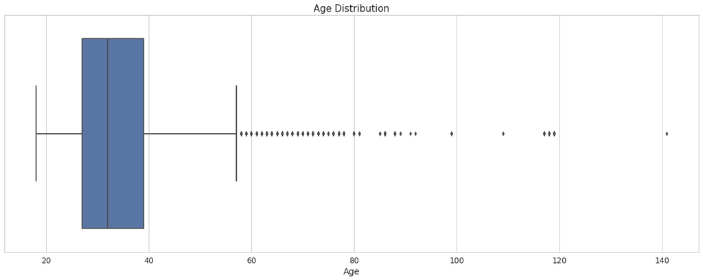

```python
age = sns.boxplot(x=df_clean["member_age"])
age.set_xlabel('Age')
age.set_title('Age Distribution');
```

*The figure above shows the upper extreme is around 58. So, that mean the age more than 58 is possible to be an outliers. I will approximate to 60 and drop all members with age more than 60 years. this will enable me to categorize the age group*

```python
df_clean.drop(df_clean[df_clean.member_age > 60].index, inplace=True)
```

```python
df_clean.member_age.describe()
```

```
count    171617.000000
mean         33.520782
std           8.953751
min          18.000000
25%          27.000000
50%          32.000000
75%          38.000000
max          60.000000
Name: member_age, dtype: float64
```

*I will categorize the age group into the following categories*

```python
def category(age):
    if 10<age<=20:
        return '11-20'

    elif 20<age<=30:
        return '21-30'

    elif 30<age<=40:
        return '31-40'

    elif 40<age<=50:
        return '41-50'

    elif 50<age<=60:
        return '51-60'

df_clean['age_category'] = df_clean['member_age'].apply(category)
```

*Check the age category*

```python
df_clean['age_category'].value_counts()
```

```
21-30    70115
31-40    63886
41-50    22050
51-60    11326
11-20     4240
Name: age_category, dtype: int64
```

### *Change of datatypes*

```python
# change the data type for start and end time to be datetime64[ns]
df_clean.start_time = pd.to_datetime(df_clean.start_time)
df_clean.end_time = pd.to_datetime(df_clean.end_time)
```

```python
# change the data type for bike_share_for_all_trip to be bool
df_clean.bike_share_for_all_trip = (df_clean.bike_share_for_all_trip == 'Yes')
```

*Change datatype of start_station_id, end_station_id and bike_id to strings*

```python
def change_to_string(df,fields):
    for field in fields:
        df[field] = df[field].astype(np.object)
    return df
```

```python
df_clean = change_to_string (df_clean,['start_station_id', 'end_station_id','bike_id'])
```

*Change datatype of user_type and member_gender to be categorical*

```python
def change_to_category(df,fields):
    for field in fields:
        df[field] = df[field].astype('category')
    return df
```

```python
df_clean = change_to_category (df_clean,['user_type', 'member_gender'])
```

*Test all the datatypes changes*

```python
df_clean.info()
```

```
<class 'pandas.core.frame.DataFrame'>
Int64Index: 179882 entries, 0 to 183411
Data columns (total 18 columns):
duration_sec               179882 non-null int64
start_time                 179882 non-null datetime64[ns]
end_time                   179882 non-null datetime64[ns]
start_station_id           179685 non-null object
start_station_name         179685 non-null object
start_station_latitude     179882 non-null float64
start_station_longitude    179882 non-null float64
end_station_id             179685 non-null object
end_station_name           179685 non-null object
end_station_latitude       179882 non-null float64
end_station_longitude      179882 non-null float64
bike_id                    179882 non-null object
user_type                  179882 non-null category
member_birth_year          171617 non-null float64
member_gender              171617 non-null category
bike_share_for_all_trip    179882 non-null bool
member_age                 171617 non-null float64
age_category               171617 non-null object
dtypes: bool(1), category(2), datetime64[ns](2), float64(6), int64(1), object(6)
memory usage: 22.5+ MB
```

Create new columns for the Visualizations.

```python
df_clean['start_time_month'] = df_clean['start_time'].dt.strftime('%B')
df_clean['start_time_monthly'] = df_clean['start_time'].dt.strftime('%y-%m')
df_clean['start_time_day']=df_clean['start_time'].dt.strftime('%A')
df_clean['start_time_hour'] = df_clean['start_time'].dt.hour
df_clean['end_time_hour'] = df_clean['end_time'].dt.hour
df_clean['duration_min'] = (df_clean['duration_sec']/60).astype(float)
df_clean.info()
```

```
<class 'pandas.core.frame.DataFrame'>
Int64Index: 179882 entries, 0 to 183411
Data columns (total 24 columns):
duration_sec               179882 non-null int64
start_time                 179882 non-null datetime64[ns]
end_time                   179882 non-null datetime64[ns]
start_station_id           179685 non-null object
start_station_name         179685 non-null object
start_station_latitude     179882 non-null float64
start_station_longitude    179882 non-null float64
end_station_id             179685 non-null object
end_station_name           179685 non-null object
end_station_latitude       179882 non-null float64
end_station_longitude      179882 non-null float64
bike_id                    179882 non-null object
user_type                  179882 non-null category
member_birth_year          171617 non-null float64
member_gender              171617 non-null category
bike_share_for_all_trip    179882 non-null bool
member_age                 171617 non-null float64
age_category               171617 non-null object
start_time_month           179882 non-null object
start_time_monthly         179882 non-null object
start_time_day             179882 non-null object
start_time_hour            179882 non-null int64
end_time_hour              179882 non-null int64
duration_min               179882 non-null float64
dtypes: bool(1), category(2), datetime64[ns](2), float64(7), int64(3), object(9)
memory usage: 30.7+ MB
```

```python
df_clean.columns
```

```
Index(['duration_sec', 'start_time', 'end_time', 'start_station_id',
       'start_station_name', 'start_station_latitude',
       'start_station_longitude', 'end_station_id', 'end_station_name',
       'end_station_latitude', 'end_station_longitude', 'bike_id', 'user_type',
       'member_birth_year', 'member_gender', 'bike_share_for_all_trip',
       'member_age', 'age_category', 'start_time_month', 'start_time_monthly',
       'start_time_day', 'start_time_hour', 'end_time_hour', 'duration_min'],
      dtype='object')
```

```python
df_clean.to_csv('fordgobike-tripdata-master.csv', sep=',', encoding='utf-8')
```

### What is the structure of your dataset?

> Each trip is anonymized and includes:
- [ ] Trip Duration (seconds)
- [ ] Start Time and Date (Month and Day)
- [ ] End Time and Date
- [ ] Start Station ID
- [ ] Start Station Name
- [ ] Start Station Latitude
- [ ] Start Station Longitude
- [ ] End Station ID
- [ ] End Station Name
- [ ] End Station Latitude
- [ ] End Station Longitude
- [ ] Bike ID
- [ ] User Type (Subscriber or Customer)
- [ ] Member Year of Birth
- [ ] Member Gender

### What is/are the main feature(s) of interest in your dataset?

> The main features are about behaviors of users..Like Where did he start and where did he end, and when? Member Gender and Age

### What features in the dataset do you think will help support your investigation into your feature(s) of interest?

> The main features that I think will help me are start and end time, distance, latitude and longitude to understand the behaviors of users. I also think that user_type, age, and gender will have effects on trip duration.

## Univariate Exploration

> In this section, we investigate distributions of individual variables.

```python
df_bike = pd.read_csv('fordgobike-tripdata-master.csv', index_col=0)
```

```python
df_bike.columns
```

```
Index(['duration_sec', 'start_time', 'end_time', 'start_station_id',
       'start_station_name', 'start_station_latitude',
       'start_station_longitude', 'end_station_id', 'end_station_name',
       'end_station_latitude', 'end_station_longitude', 'bike_id', 'user_type',
       'member_birth_year', 'member_gender', 'bike_share_for_all_trip',
       'member_age', 'age_category', 'start_time_month', 'start_time_monthly',
       'start_time_day', 'start_time_hour', 'end_time_hour', 'duration_min'],
      dtype='object')
```

```python
# https://stackoverflow.com/questions/19412462/getting-distance-between-two-points-based-on-latitude-longitude
from math import sin, cos, sqrt, atan2, radians

def distance (lat1,lon1,lat2,lon2):
    R = 6373.0

    lat1 = radians(lat1)
    lon1 = radians(lon1)
    lat2 = radians(lat2)
    lon2 = radians(lon2)

    dlon = lon2 - lon1
    dlat = lat2 - lat1

    a = sin(dlat / 2)**2 + cos(lat1) * cos(lat2) * sin(dlon / 2)**2
    c = 2 * atan2(sqrt(a), sqrt(1 - a))

    distance = R * c
    return np.float64(round(1000*distance))
```

```python
df_bike['distance'] = df_bike.apply(lambda row: distance(row['start_station_latitude'],row['start_station_longitude'],row['end_station_latitude'],row['end_station_longitude']),axis=1)
```

### 1. What is the distance distribution in the dataset

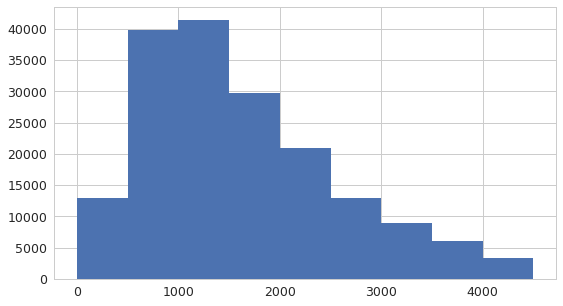

```python
bin_edges = np.arange(0, (2133+ 1.5*1247)+500,500)
plt.figure(figsize = [9, 5])
plt.hist(data = df_bike, x ='distance', bins = bin_edges);
```

observation: most of the Destinations traveled are between 500 to 2000 meters

```python
df_bike.distance.describe()
```

```
count    179882.000000
mean       1693.383657
std        1096.534895
min           0.000000
25%         916.000000
50%        1434.000000
75%        2229.000000
max       69491.000000
Name: distance, dtype: float64
```

### When are the most trips taken?

*We would look at when the most trips are taken by weekday*

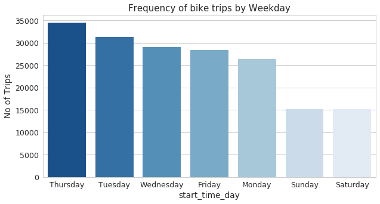

```python
plt.figure(figsize = [10, 5])
week_order = df_bike['start_time_day'].value_counts().index

sns.countplot(data = df_bike, x = 'start_time_day', order = week_order, palette = 'Blues_r')
plt.xticks(rotation = 0)
plt.xlabel('start_time_day')
plt.ylabel('No of Trips')
plt.title('Frequency of bike trips by Weekday');
```

**Observation** >

> From the charts above, we can see the frequency of bike trips by week. Most bike trips are taken on Thursday then followed by Tuesday

### What is the distribution by user type?

```python
df_bike['user_type'].value_counts()
```

```
Subscriber    160208
Customer       19674
Name: user_type, dtype: int64
```

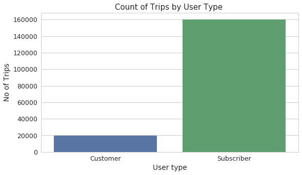

```python
plt.figure(figsize = [9, 5])
plot = sns.countplot(data=df_bike, x='user_type')
plt.xlabel('User type')
plt.ylabel('No of Trips')
plt.title("Count of Trips by User Type ")

plt.show()
```

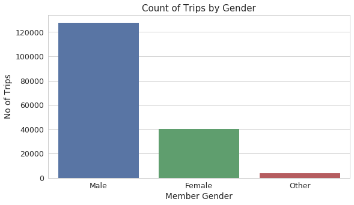

```python
plt.figure(figsize = [9, 5])
plot = sns.countplot(data=df_bike, x='member_gender',  order = ['Male','Female','Other'])
plt.xlabel('Member Gender')
plt.ylabel('No of Trips')
plt.title("Count of Trips by Gender")
plt.show()
```

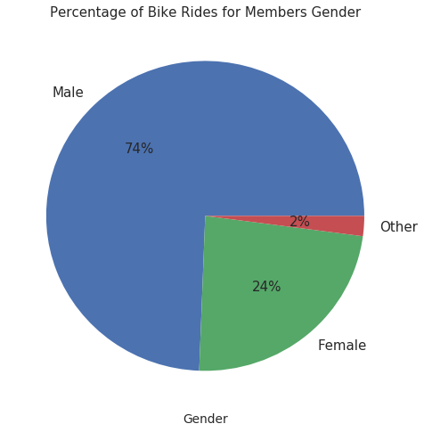

```python
df_bike.member_gender.value_counts().plot(kind='pie', figsize=(8,8),fontsize =15, autopct='%1.0f%%')

ax = plt.gca()
ax.set_ylabel('')
ax.set_xlabel('Gender')
ax.set_title("Percentage of Bike Rides for Members Gender", fontsize=15);
```

The chart above shows that the majority of the users are Male followed by female

So, we can see male gender is the highest with 74%, female at 24% and 2% for other

### What is the number & percentage of bike rides for the age category?

```python
nm_category_df = df_bike.groupby('age_category').agg({'bike_id':'count'})
nm_category_df['percentage'] = (nm_category_df['bike_id']/nm_category_df['bike_id'].sum())*100
nm_category_df
```

| age_category | bike_id | percentage |
| --- | --- | --- |
| 11-20 | 4240 | 2.470618 |
| 21-30 | 70115 | 40.855510 |
| 31-40 | 63886 | 37.225916 |
| 41-50 | 22050 | 12.848377 |
| 51-60 | 11326 | 6.599579 |

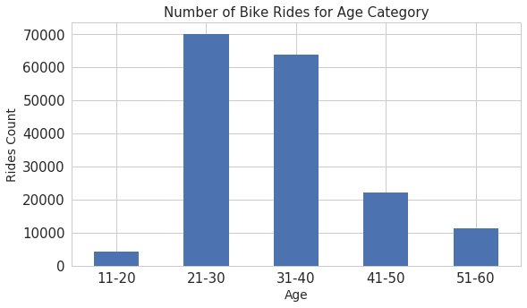

```python
nm_category_df.bike_id.plot(kind='bar', figsize=(9,5),fontsize =15, color=base_color)

plt.xticks(rotation=0)
ax = plt.gca()
ax.set_ylabel('Rides Count')
ax.set_xlabel('Age')
ax.set_title("Number of Bike Rides for Age Category", fontsize=15);
```

> The chart above shows the number of rides (trips) for each age categories. *age group 21-30 have the higest number of trips followed by age group 31-40*

## Bivariate Exploration

> In this section, investigate relationships between pairs of variables in your data. Make sure the variables that you cover here have been introduced in some fashion in the previous section (univariate exploration).

### What is the daily usage of bike rides by gender

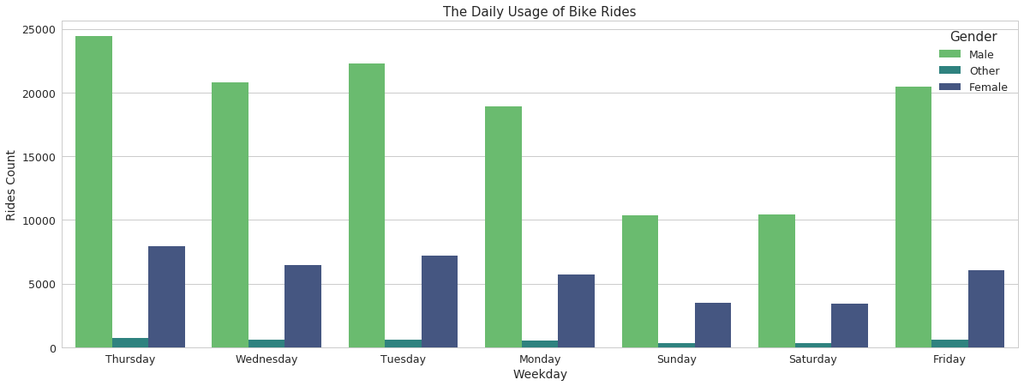

```python
plot = sns.countplot(data=df_bike, x='start_time_day', hue='member_gender', color=base_color,
                palette='viridis_r')
plot.legend().set_title('Gender')
plot.set_ylabel('Rides Count')
plot.set_xlabel('Weekday')
plot.set_title('The Daily Usage of Bike Rides', fontsize=15);
```

The chart above shows the number of rides (trips) per day, and we can see the weekend it is has the lowest number of rides for both male and female.

### What is the trip count of member gender by age category

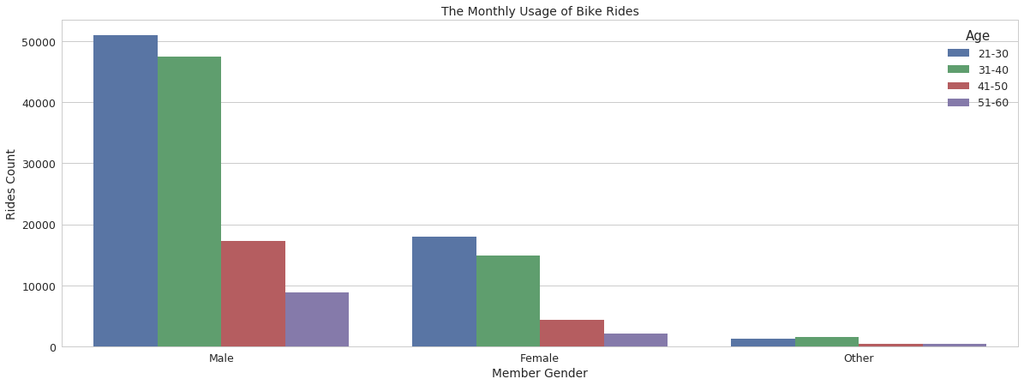

```python
my_order = ['21-30', '31-40', '41-50', '51-60']
ax = sns.countplot(x='member_gender', hue='age_category', hue_order=my_order,
                   data=df_bike[df_bike['age_category'].isin(['21-30', '31-40', '41-50', '51-60'])]
                   .sort_values(by=['start_time_monthly']))
ax.legend().set_title('Age')
ax.set_ylabel('Rides Count')
ax.set_xlabel('Member Gender')
ax.set_title("The Monthly Usage of Bike Rides", fontsize=14);
```

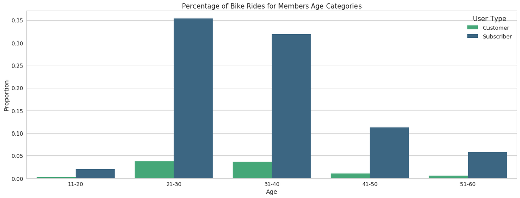

```python
n_points = df_bike.shape[0]

max_count_age = df_bike['age_category'].value_counts().max()
max_prop_age = max_count_age / n_points

tick_props_age = np.arange(0, max_prop_age, 0.05)
tick_names_age = ['{:0.2f}'.format(v) for v in tick_props_age]

my_order = ['11-20', '21-30', '31-40', '41-50', '51-60']
sns.countplot(data=df_bike, x='age_category', hue='user_type', order=my_order, palette='viridis_r')

ax = plt.gca()
ax.legend().set_title('User Type')
plt.yticks(tick_props_age * n_points, tick_names_age)
ax.set_ylabel('Proportion')
ax.set_xlabel('Age')
ax.set_title("Percentage of Bike Rides for Members Age Categories", fontsize=15);
```

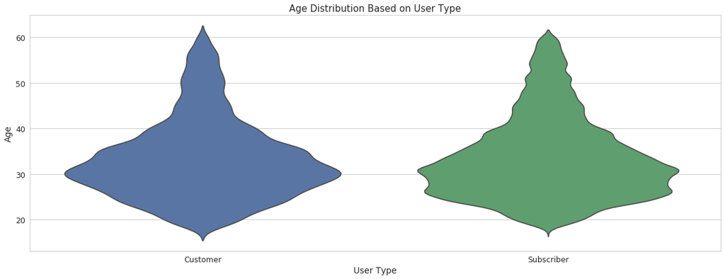

```python
sns.violinplot(data=df_bike, x='user_type', y='member_age', inner=None, height=12)

ax = plt.gca()
ax.set_ylabel('Age')
ax.set_xlabel('User Type')
ax.set_title("Age Distribution Based on User Type", fontsize=15);
```

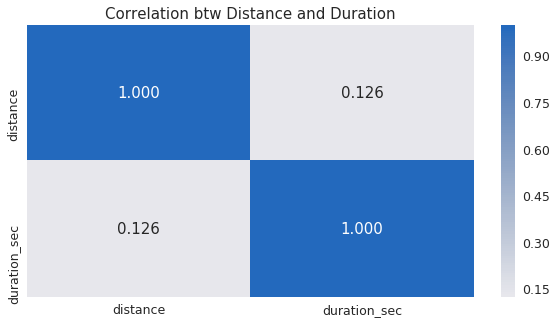

```python
numeric_vars = ['distance', 'duration_sec']
plt.figure(figsize = [10, 5])

sns.heatmap(df_bike[numeric_vars].corr(), annot = True, fmt = '.3f', cmap = 'vlag_r', center = 0)
plt.title('Correlation btw Distance and Duration');
```

[figure not shown]

```python
#checking for correlation between duration_sec and distance using scatter plot, using a sample size 1000 from the dataset
df_samp = df_bike.sample(n = 1000, replace = False)

plt.figure(figsize = [10, 5])

plt.scatter(data = df_samp, x = 'duration_sec', y = 'distance', alpha = 1/5)
plt.xscale('log')
plt.xticks([100, 300, 1000, 3000, 10000, 80000], [100, 300, '1k', '3k','10k', '80k'])
plt.xlim([0, 15000])
plt.xlabel('Duration(sec)')
plt.ylabel('Distance(km)')
plt.title('Correlation between Distance and Duration', size = 15);
```

Looking at the heatmap correlation plots for the Datasets, correlation between distance and duration is about 0.126. This is a very low positive correlation that might suggest that there are no strong correlations between both variables. Checking a sample of the dataset with a scatter plot shows a somewhat positive correlation; although weak as established by the correlation plot. This plot does not necessarily suggest that bike trips with longer duration mean longer distances.

## Multivariate Exploration

> Create plots of three or more variables to investigate your data even further. Make sure that your investigations are justified, and follow from your work in the previous sections.

The main thing I want to explore in this part of the analysis is how the three categorical measures of user type and gender into the relationship between trip duration and age.

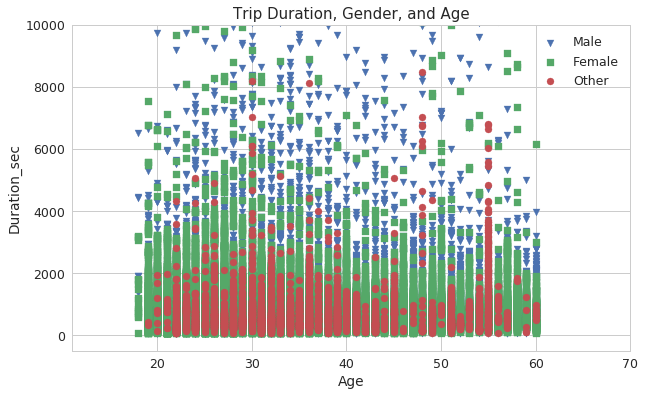

```python
gender_mark = [['Male', 'v'],['Female', 's'],['Other', 'o']]
plt.figure(figsize = [10, 6])

for gender, marker in gender_mark:
    df_gender = df_bike[df_bike['member_gender'] == gender]
    plt.scatter((2019 - df_gender['member_birth_year']), df_gender['duration_sec'], marker = marker, alpha= 1)
plt.legend(['Male','Female','Other'])
plt.axis([11, 70, -500, 10000 ])
plt.title('Trip Duration, Gender, and Age')
plt.xlabel('Age')
plt.ylabel('Duration_sec')
plt.show()
```

The plot is not clear, so let's separate all three genders into different graphs.

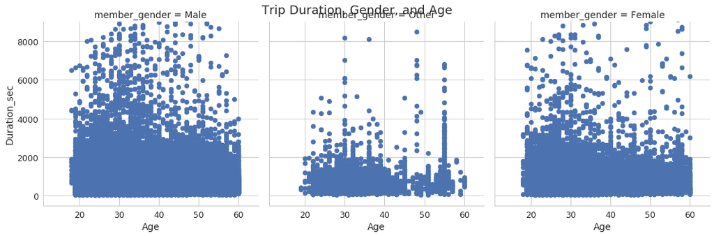

```python
df_bike['age'] = (2019 - df_bike['member_birth_year'])
gender = sns.FacetGrid(data = df_bike, col = 'member_gender', col_wrap = 3, size = 5,
                 xlim = [11, 65], ylim = [-500, 9000])
gender.map(plt.scatter, 'age', 'duration_sec', alpha= 1)


gender.set_xlabels('Age')
gender.set_ylabels('Duration_sec')
gender.fig.suptitle('Trip Duration, Gender, and Age')
plt.show()
```

### What is the Correlation between each variable in the dataset?

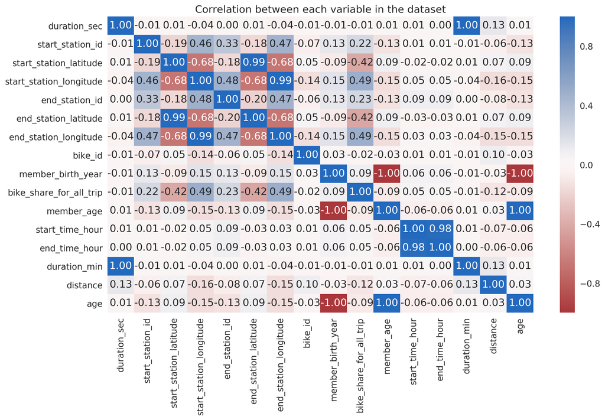

```python
plt.figure(figsize = (14,8), dpi = 200)



sns.heatmap(df_bike.corr(), annot = True, fmt = '.2f', cmap = 'vlag_r', center = 0)

plt.title("Correlation between each variable in the dataset")


plt.xticks(rotation = 90)


plt.legend(bbox_to_anchor=(1.05, 1), loc='upper left')



plt.show()
```

*The charts above show how Correlation between each variables in the dataset using heatmap plots*

- There is no Correlation for any variable with time ( duration sec /minutes/hours)
- There is a weak Correlation between start_station_id with start_station_longitude and end_station_longitude
- There is a strong Correlation between start station longitude and end_station longitude, so we can say that the station location is good factor to determine user behaviour

## Conclusions

> Most users were Male.

> Most users were subscriber.

> The female distribution depending on their Age more than male

> Finally, there were no strong or specific relationships between most of the variables. The correlation observed between distance and duration was a weak correlation and does not necessarily suggest that either variable affects the other.

## Limitation

> We got missing data which we fix some of them .

> We have outliers in member age, people aged 140 years will probably not ride a bike. this outlierss was dropped during the analysis

> Price points for the bike trip either per duration or bike type would have been very useful too. These information can be used to further understand what factors influence a customer behavior in relation to their bike trips.